# Visualization of Single-Cell Transcriptomics of Zebrafish Pigment Cells

Diogo Esteves

2024-05-17

Este ficheiro efetua os downloads dos dados automaticamente à medida que avançamos na análise, as próximas secções detalham a origem destes dados.

# Configuração do Ambiente

Passo importante para definir a diretoria para os downloads e ficheiros de apoio, está definida para ser a localização deste ficheiro na máquina.

```r
setwd(dirname(rstudioapi::getSourceEditorContext()$path))
```

# Links:

## Dados:

https://cole-trapnell-lab.github.io/zscape/

## Código e Dados Fonte

Os dados que não estão disponíveis nos repositórios GEO, estão disponíveis: https://github.com/cole-trapnell-lab/sdg-zfish

## Repositorios GEO:

### GSE202639

O desenvolvimento de atlas celulares compreensivos de embriões inteiros foi facilitado pela evolução das tecnologias de transcritômica de célula única. Mas a maioria desses dados foi coletada de embriões selvagens sem levar em consideração a variação latente no desenvolvimento. Apresentamos dados de transcritômica de célula única de 3,2 milhões de células de embriões de peixe-zebra em desenvolvimento de 1812, que incluem 19 pontos de tempo e 23 perturbações genéticas. A alta replicação deste estudo (8 ou mais embriões por condição) permite estimar as variações na abundância de tipos celulares em todo o organismo e identificar desvios dependentes de perturbação na composição de tipos celulares em comparação com embriões selvagens. A técnica por eles utilizada é sensível a tipos celulares raros, resolvendo trajetórias de desenvolvimento e dependências genéticas nos neurônios dos gânglios cranianos, uma população celular que representa menos de 1% do embrião: https://www.ncbi.nlm.nih.gov/geo/query/acc.cgi?acc=GSE202639

### GSE112294

Perfil de expressão de sequenciação de alta qualidade. O mapeamento de alta taxa de diferenciação celular a partir de dados de célula única promete facilitar investigações sistemáticas sobre o desenvolvimento e doenças em vertebrados. Aqui, aplicamos sequenciação de RNA de célula única a mais de 92,000 células de embriões de peixe-zebra durante o primeiro dia de desenvolvimento: https://www.ncbi.nlm.nih.gov/geo/query/acc.cgi?acc=GSE112294 ou: http://zebrafish-dev.cells.ucsc.edu/

# Hashing de oligonucleotidos para transcritómica de peixe-zebra em células únicas

## Download dos Dados

Ficheiros: https://www.ncbi.nlm.nih.gov/geo/query/acc.cgi?acc=GSE202639

- AVISO: São muitos GBs. Certifiquem-se que a máquina reúne os requisitos, que estão na diretoria certa e a correr em modo administrador antes de avançar mais no script.
- PASSO DEMORADO, mediante a velocidade de rede e a máquina usada. Necessário cumprir com todos os pré-requisitos de pacotes e dependências até aqui.

```r
# Configurar o diretório de trabalho para o diretório deste ficheiro .Rmd
setwd(dirname(rstudioapi::getSourceEditorContext()$path))

# URLs dos ficheiros
url_utils <- "https://raw.githubusercontent.com/cole-trapnell-lab/sdg-zfish/main/figure_code/saunders_srivatsan_2023_utils.R"
url_ref_cds <- "https://www.ncbi.nlm.nih.gov/geo/download/?acc=GSE202639&format=file&file=GSE202639%5Freference%5Fcds%2ERDS%2Egz"

# Definir nomes dos arquivos
utils <- "saunders_srivatsan_2023_utils.R"
ref_cds_gz <- "GSE202639_reference_cds.RDS.gz"
ref_cds <- "GSE202639_reference_cds.RDS"


# Função para verificar, baixar e extrair arquivos. Apenas executa novamente o download e a extração caso não estejam presentes estes ficheiros nesta diretoria
options(timeout = 1200) #20minutos para tempo máximo de download, aumentar se a net for lenta
download_file_if_not_exists <- function(url, file_name) {
  if (!file.exists(file_name)) {
    message("Downloading ", file_name, " from ", url)
    download.file(url, file_name)
    if (grepl(".gz$", file_name)) {
      R.utils::gunzip(file_name, overwrite = TRUE)
    }
  } else {
    message(file_name, " already exists.")
  }
}

# Baixar e carregar os arquivos
download_file_if_not_exists(url_utils, utils)
```

```
## saunders_srivatsan_2023_utils.R already exists.
```

```r
download_file_if_not_exists(url_ref_cds, ref_cds_gz)
```

```
## GSE202639_reference_cds.RDS.gz already exists.
```

```r
# Carregar o script com funções de apoio (from Zscape)
source(utils)
```

## Carregamento dos dados

Nesta secção, os dados descarregados são lidos e preparados para análise.

```r
# Ler o arquivo descomprimido
ref_cds <- readRDS("GSE202639_reference_cds.RDS")

ref_coldata <-
  ref_cds %>%
  colData() %>%
  as.data.frame()
```

## Definir cores para os tempos de amostragem

Aqui definimos as cores que serão usadas para representar diferentes pontos de tempo.

```r
#utilizei as mesmas cores da figura 1 do artigo do projeto ZScape

rainbow_timepoint_colors <-
  c("18h" = "#DF4828",
    "24h" = "#E78C35",
    "36h" = "#F6C141",
    "48h" = "#4EB265",
    "72h" = "#1965B0")

num_colors <- ref_coldata %>%
  filter(!is.na(timepoint)) %>%
  pull(timepoint) %>%
  unique() %>%
  sort() %>%
  length()

full_spectrum_timepoint <- colorRampPalette(rainbow_timepoint_colors)(num_colors)

names(full_spectrum_timepoint) <- ref_coldata %>%
  filter(!is.na(timepoint)) %>%
  pull(timepoint) %>%
  unique() %>%
  sort()
```

## Espaço amostral

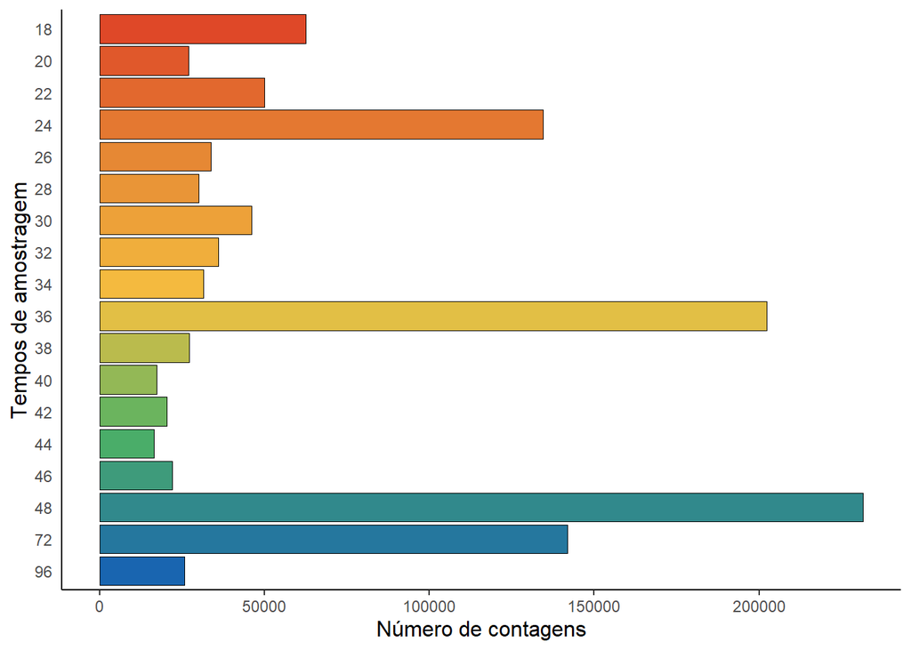

```r
ggplot(ref_coldata %>%
         group_by(timepoint) %>%
         summarise(n = n()) %>%
         drop_na()) +
  geom_bar(aes(x = reorder(as.character(timepoint), -timepoint),
               y = n,
               fill = as.character(timepoint)),
           stat = "identity",
           color = "black",
           linewidth = 0.2) +
  theme_classic() +
  theme(legend.position = "none",
        axis.title.x = element_text(size = 12),
        axis.title.y = element_text(size = 12),
        plot.background = element_blank(),
        axis.ticks.y = element_blank(),
        panel.background = element_blank()) +
  labs(x = "Tempos de amostragem", y = "Número de contagens") +
  scale_fill_manual(values = full_spectrum_timepoint) +
  coord_flip()
```

```r
ggsave("fig1_barplot.png",
       dpi = 750,
       height = 3,
       width = 1,
       bg = "transparent")
```

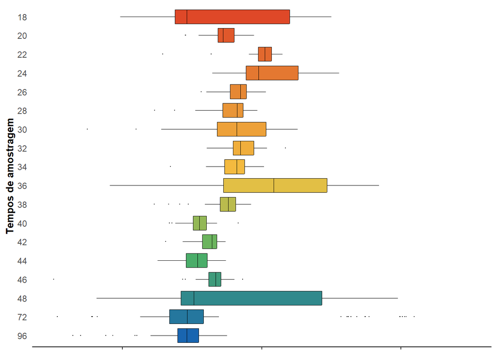

```r
# Gráfico de Boxplot
ggplot(ref_coldata %>%
         group_by(timepoint, Oligo) %>%
         summarise(n = n(), .groups = 'drop') %>%
         drop_na()) +
  geom_boxplot(aes(x = reorder(as.character(timepoint), -timepoint),
                   y = log10(n),
                   fill = as.character(timepoint)),
               color = "black",
               size = 0.1,
               outlier.size = 0.2,
               outlier.stroke = 0) +
  theme_classic() +
  scale_y_continuous(breaks = c(2, 3, 4), limits = c(1.5, 4.5)) +
  labs(x = "Tempos de amostragem", y = NULL) +  # Define o título do eixo y e remove o título do eixo x, notem que apesar de estar ao contrario no grafico aparece correto
  theme(legend.position = "none",
        axis.text.y = element_text(),
        axis.title.y = element_text(size = 10, face = "bold"),  # Ajusta o estilo do título do eixo y
        plot.background = element_blank(),
        axis.text.x = element_blank(),
        axis.ticks.y = element_blank(),
        axis.line.y = element_blank(),
        panel.background = element_blank()) +
  scale_fill_manual(values = full_spectrum_timepoint) +
  coord_flip()
```

```r
ggsave("fig2_boxplot.png",
         dpi = 750,
         height = 3,
         width = 0.5,
         bg = "transparent")
```

## UMAP

```r
vibrant.colors <-
  c('#EE7733', '#0077BB', '#228833', '#33BBEE', '#EE3377', '#CC3311',
    '#AA3377', '#009988', '#004488', '#DDAA33', '#99CC66','#D590DD')

bright.colors <-
  c('#4477AA',
    '#EE6677',
    '#228833',
    '#CCBB44',
    '#66CCEE',
    '#AA3377',
    '#BBBBBB')


num.colors.tissue <-
  ref_coldata %>%
  filter(!is.na(tissue)) %>%
  pull(tissue) %>%
  unique() %>%
  sort() %>%
  length()

tissue.colors <- colorRampPalette(c(vibrant.colors,bright.colors))(num.colors.tissue)
```

### 24h

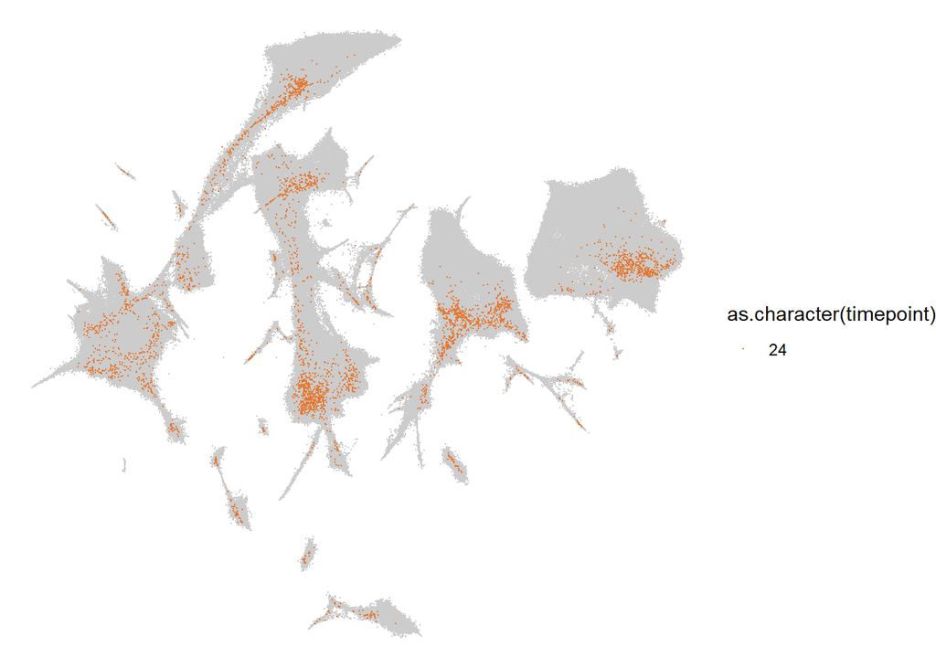

```r
# Individual UMAP 24hours
ggplot(ref_coldata %>%
         sample_n(size = dim(ref_coldata)[1]) %>%
         filter(!is.na(timepoint))) +
  geom_point(aes(x = umap3d_1,
                 y = umap3d_2),
             color = "grey80",
             stroke = 0,
             size = 0.1) +
  geom_point(data = ref_coldata %>%
               filter(Oligo == "24h_ctrl-inj_P10_H7"),
             aes(x = umap3d_1,
                 y = umap3d_2,
                 color = as.character(timepoint)),
             stroke = 0,
             size = 0.125) +
  theme_void() +
  theme(legend.position = "right") +
  scale_color_manual(values = full_spectrum_timepoint)
```

```r
ggsave("fig3_umap_24h.png",
         dpi = 600,
         height = 1,
         width = 1,
         bg = "transparent")
```

### 48h

a resolver este problema…

[figure not shown]

```r
ggplot(ref_coldata %>%
         sample_n(size = dim(ref_coldata)[1]) %>%
         filter(!is.na(timepoint))) +
  geom_point(aes(x = umap3d_1,
                 y = umap3d_2),
             color = "grey80",
             stroke = 0,
             size = 0.1) +
  geom_point(data = ref_coldata %>%
               filter(Oligo == "48h_ctrl-inj_P2_D11"),
             aes(x = umap3d_1,
                 y = umap3d_2,
                 color = as.character(timepoint)),
             stroke = 0,
             size = 0.125) +
  theme_void() +
  theme(legend.position = "right") +
  scale_color_manual(values = full_spectrum_timepoint)
```

```r
ggsave("fig4_umap_48h.png",
         dpi = 600,
         height = 1,
         width = 1,
         bg = "transparent")
```

### Resultado final

a resolver a legenda

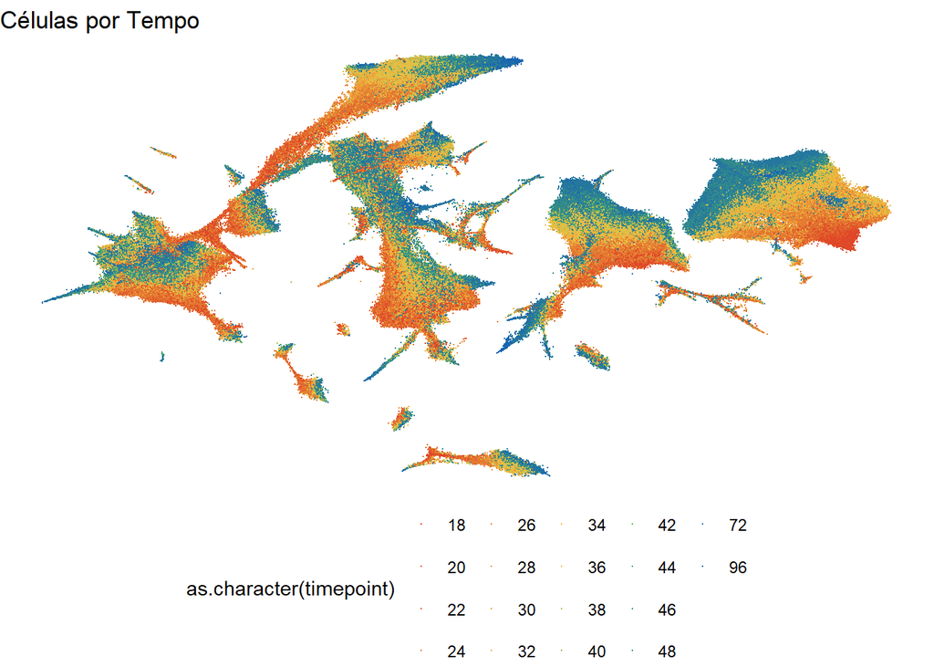

```r
# plotar células por tempo
ggplot(ref_coldata %>%
         sample_n(size = dim(ref_coldata)[1]) %>%
         filter(!is.na(timepoint))) +
  geom_point(aes(x = umap3d_1,
                 y = umap3d_2),
             color = "black",
             stroke = 0,
             size = 0.15) +
  geom_point(aes(x = umap3d_1,
                 y = umap3d_2,
                 color = as.character(timepoint)),
             stroke = 0,
             size = 0.11) +
  theme_void() +
  theme(legend.position = "bottom") +  # Define a posição da legenda
  scale_color_manual(values = full_spectrum_timepoint) +
  ggtitle("Células por Tempo")
```

```r
ggsave("fig5_umap_tempos.png",
         dpi = 750,
         height = 1.5,
         width = 1.5,
         bg = "transparent")
```

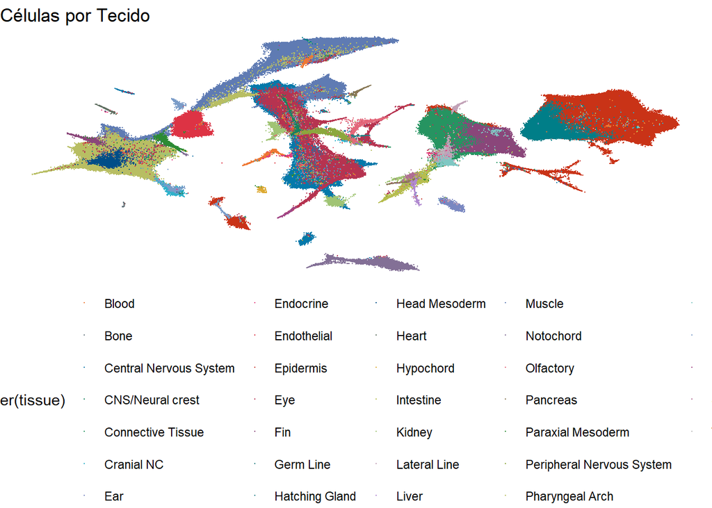

```r
# plotar células por tecido
ggplot(ref_coldata %>%
         sample_n(size = dim(ref_coldata)[1]) %>%
         filter(!is.na(timepoint)) %>%
         group_by(tissue) %>%
         add_tally() %>%
         arrange(-n)) +
  geom_point(aes(x = umap3d_1,
                 y = umap3d_2),
             color = "black",
             stroke = 0,
             size = 0.2) +
  geom_point(aes(x = umap3d_1,
                 y = umap3d_2,
                 color = as.character(tissue)),
             stroke = 0,
             size = 0.15) +
  theme_void() +
  theme(legend.position = "bottom") +  # Define a posição da legenda
  scale_color_manual(values = tissue.colors) +
  ggtitle("Células por Tecido")
```

```r
ggsave("fig6_umap_tecidos.png",
         dpi = 1200,
         height = 3,
         width = 3,
         bg = "transparent")
```

## Testes de variancia

### teste 1

```r
# Baixar o arquivo
if (!file.exists("ref_broad_celltype_disps.csv")) {
  download.file("https://raw.githubusercontent.com/cole-trapnell-lab/sdg-zfish/main/data/ref_broad_celltype_disps.csv", "ref_broad_celltype_disps.csv")
} else {
    message("ref_broad_celltype_disps.csv", " already exists.")
}
```

```
## ref_broad_celltype_disps.csv already exists.
```

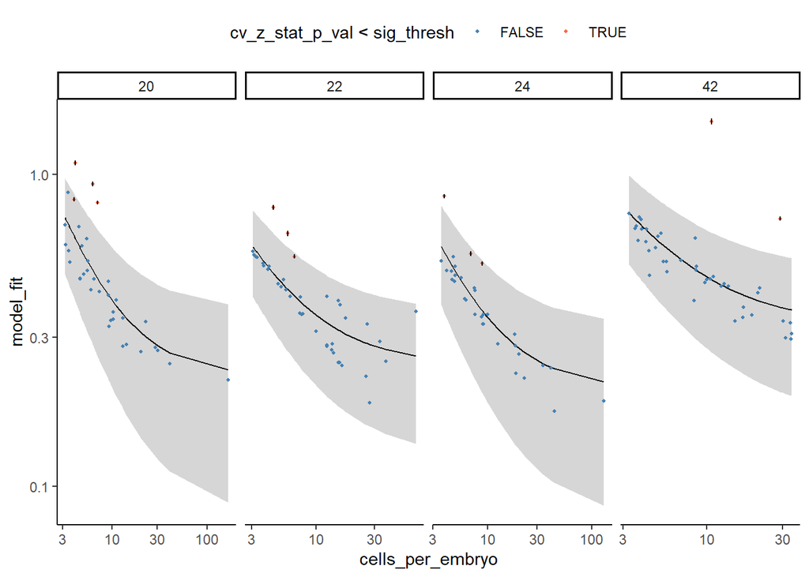

```r
# Carregar os dados
celltype_disps <- fread("ref_broad_celltype_disps.csv",
                        sep = ",", stringsAsFactors = F,
                        data.table = F)

# set thresholds
sig_thresh = 0.05
times = c(20, 22, 24, 42)

plot_df = celltype_disps %>%
  filter(cells_per_embryo > 3) %>%
  filter(timepoint %in% times)

# plot variance faceted by time
ggplot(data=plot_df) +
  geom_line(aes(cells_per_embryo, model_fit), color="black", data=plot_df) +
  geom_ribbon(aes(cells_per_embryo, ymin=model_fit_lower, ymax=model_fit_upper), alpha=0.2) +
  geom_point(aes(cells_per_embryo, cells_per_embryo_cv, color=cv_z_stat_p_val < sig_thresh), size = 0.75) +
  geom_linerange(aes(cells_per_embryo,
                     ymin=cells_per_embryo_cv - cells_per_embryo_cv.stderr,
                     ymax=cells_per_embryo_cv + cells_per_embryo_cv.stderr),
                 data=plot_df %>% filter(cv_z_stat_p_val < sig_thresh)) +
  facet_wrap(~timepoint, scales = "free_x", nrow = 1) +
  scale_color_manual(values = c("steelblue", "tomato")) +
  scale_y_log10() +
  scale_x_log10() +
  theme_classic() +
  theme(legend.position = "top")
```

```r
ggsave("fig7_variancia_tempos.pdf",
       width = 5,
       height = 2.2)
```

### teste 2

Após este teste e gráfico consequente, focarei apenas nas celulas pigmentares e transciptómica associada a estas:

- xanthophores (yellow)
- erythrophores (red)
- iridophores (reflective / iridescent)
- leucophores (white)
- melanophores (black/brown)
- cyanophores (blue)

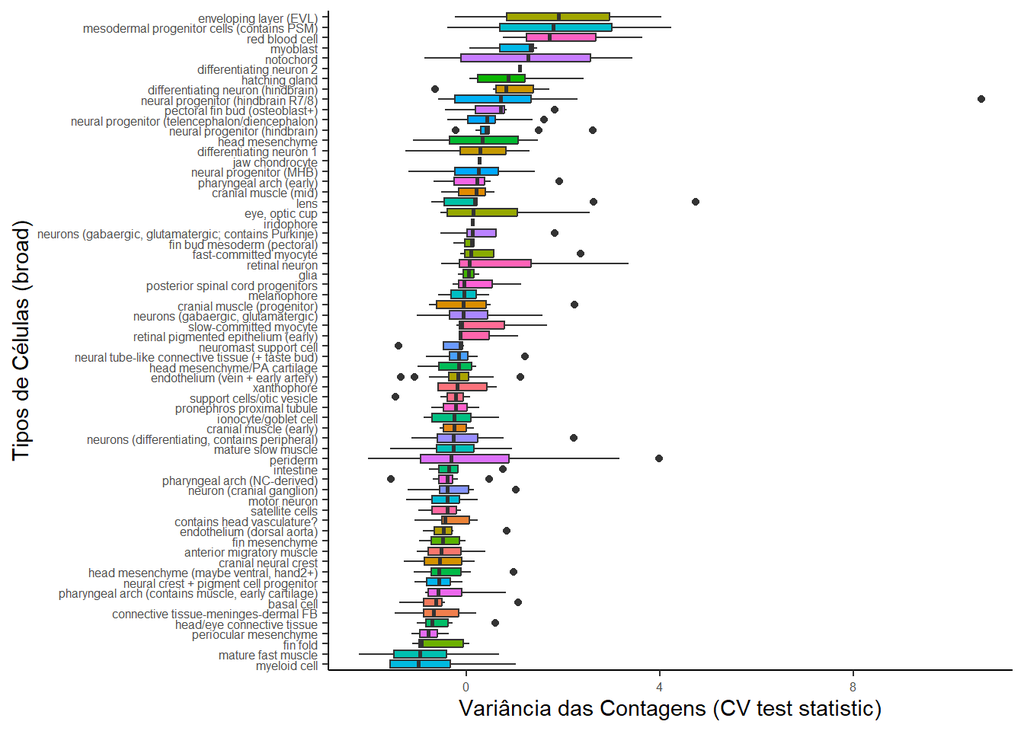

```r
ggplot(celltype_disps %>%
         filter(cells_per_embryo > 3),
       aes(x = reorder(cell_group, cv_test_stat, FUN = median), y = cv_test_stat, fill = cell_group)) +
  geom_boxplot() +
  coord_flip() +
  theme_classic() +
  xlab("Tipos de Células (broad)") +
  ylab("Variância das Contagens (CV test statistic)") +
  theme(legend.position = "none",
        axis.text = element_text(size = 6),
        axis.line = element_line(), axis.ticks = element_line())
```

```r
ggsave(filename = "Fig8_varianciatotal_boxplot.pdf", width = 8, height = 8)
```